# Bellabeat Data Analysis

Salah Eddine EL KHIRANI

2024-08-08

[figure not shown]

## Introduction

This R Markdown document contains the analysis for the Bellabeat case study. The goal is to analyze smart device usage data to gain insights into how consumers use non-Bellabeat smart devices, and then select one Bellabeat product to apply these insights to in our final presentation.

## Business Task

Our main business tasks are:

1. Identify trends in smart device usage
2. Apply these trends to Bellabeat customers
3. Use these insights to influence Bellabeat’s marketing strategy

## Data Preparation

First, we’ll load the necessary libraries and import our data:

```r
library(tidyr)
library(dplyr)
library(lubridate)
library(janitor)

# Specify the directory containing the CSV files
data_dir <- "C:/Users/33775/Documents/Data Analyst/Other/bellabeat data/archive/mturkfitbit_export_4.12.16-5.12.16/Fitabase Data 4.12.16-5.12.16/"

# Get a list of all CSV files in the directory
csv_files <- list.files(data_dir, pattern = "*.csv", full.names = TRUE)

# Loop through each file, read the CSV, and assign it to a variable
for (csv_file in csv_files) {
  # Extract the file name without the extension
  file_name <- tools::file_path_sans_ext(basename(csv_file))

  # Create a variable name based on the file name
  var_name <- make.names(file_name)

  # Read the CSV file
  data <- read.csv(csv_file)

  # Assign the data frame to a variable with the name derived from the file name
  assign(var_name, data)
}

# Verify that the variables have been created
ls()
```

```
##  [1] "csv_file"                       "csv_files"
##  [3] "dailyActivity_merged"           "dailyCalories_merged"
##  [5] "dailyIntensities_merged"        "dailySteps_merged"
##  [7] "data"                           "data_dir"
##  [9] "file_name"                      "heartrate_seconds_merged"
## [11] "hourlyCalories_merged"          "hourlyIntensities_merged"
## [13] "hourlySteps_merged"             "minuteCaloriesNarrow_merged"
## [15] "minuteCaloriesWide_merged"      "minuteIntensitiesNarrow_merged"
## [17] "minuteIntensitiesWide_merged"   "minuteMETsNarrow_merged"
## [19] "minuteSleep_merged"             "minuteStepsNarrow_merged"
## [21] "minuteStepsWide_merged"         "sleepDay_merged"
## [23] "var_name"                       "weightLogInfo_merged"
```

## Limitations of Data

1. Where is your data stored?
   - The data is stored on Kaggle and can be accessed through the following link: [FitBit Fitness Tracker Data](https://www.kaggle.com/datasets/arashnic/fitbit).
2. How is the data organized? Is it in long or wide format?
   - The data is organized in long format, where each row represents a single observation and includes multiple entries for each user across different times or dates.
3. Are there issues with bias or credibility in this data? Does your data ROCCC?
   - The data may have some limitations in terms of sample size and representativeness, as it only includes data from thirty users who consented to share their information. This could introduce selection bias. Additionally, the credibility of the data is dependent on the accuracy of the Fitbit devices and the honesty of the users. To ensure the data ROCCC (Reliable, Original, Comprehensive, Current, Consistent), it’s important to cross-verify with other data sources and understand the context in which the data was collected.
4. How are you addressing licensing, privacy, security, and accessibility?
   - The data is under the CC0: Public Domain license, which means it can be freely used for any purpose. Privacy and security are maintained as the dataset does not contain personally identifiable information (PII). Accessibility is ensured as the data is available publicly on Kaggle.
5. How did you verify the data’s integrity?
   - Data integrity can be verified by checking for consistency in data entries, such as ensuring there are no missing or duplicate records and that the data values are within expected ranges. Cross-referencing with similar datasets or performing sanity checks can also help verify integrity.
6. How does it help you answer your question?
   - The data provides insights into users’ daily habits related to physical activity, heart rate, and sleep patterns. These insights are crucial for understanding trends and behaviors in smart device usage, which can inform Bellabeat’s marketing strategies and product improvements.
7. Are there any problems with the data?
   - Potential problems with the data include:
     - Small sample size, which may not be representative of the broader population.
     - Incomplete data or missing values that could affect the analysis.
     - Possible inaccuracies in self-reported or device-recorded data.
     - Lack of demographic diversity, which may limit the generalizability of the findings. Process

## Data Cleaning and Processing

Number of distinct users in each dataset

```r
n_distinct(dailyActivity_merged$Id)
```

```
## [1] 33
```

```r
n_distinct(hourlyIntensities_merged$Id)
```

```
## [1] 33
```

```r
n_distinct(sleepDay_merged$Id)
```

```
## [1] 24
```

```r
n_distinct(weightLogInfo_merged$Id)
```

```
## [1] 8
```

The analysis reveals the number of participants within each dataset. There are 33 participants in the activity and intensities datasets, 24 in the sleep dataset, and only 8 in the weight dataset. The small sample size of 8 participants in the weight data is insufficient to draw any meaningful conclusions or make reliable recommendations based on this data.

Now, let’s clean and process our data:

```r
#remove duplicates and NA
dailyActivity_merged <- dailyActivity_merged %>%
  distinct() %>%
  drop_na()


hourlyIntensities_merged <- hourlyIntensities_merged %>%
  distinct() %>%
  drop_na()

sleepDay_merged <- sleepDay_merged %>%
  distinct() %>%
  drop_na()

weightLogInfo_merged <- weightLogInfo_merged %>%
  distinct() %>%
  drop_na(Id, BMI, WeightKg)

# Display summary and view data
summary(dailyActivity_merged)
```

```
##        Id            ActivityDate         TotalSteps    TotalDistance
##  Min.   :1.504e+09   Length:940         Min.   :    0   Min.   : 0.000
##  1st Qu.:2.320e+09   Class :character   1st Qu.: 3790   1st Qu.: 2.620
##  Median :4.445e+09   Mode  :character   Median : 7406   Median : 5.245
##  Mean   :4.855e+09                      Mean   : 7638   Mean   : 5.490
##  3rd Qu.:6.962e+09                      3rd Qu.:10727   3rd Qu.: 7.713
##  Max.   :8.878e+09                      Max.   :36019   Max.   :28.030
##  TrackerDistance  LoggedActivitiesDistance VeryActiveDistance
##  Min.   : 0.000   Min.   :0.0000           Min.   : 0.000
##  1st Qu.: 2.620   1st Qu.:0.0000           1st Qu.: 0.000
##  Median : 5.245   Median :0.0000           Median : 0.210
##  Mean   : 5.475   Mean   :0.1082           Mean   : 1.503
##  3rd Qu.: 7.710   3rd Qu.:0.0000           3rd Qu.: 2.053
##  Max.   :28.030   Max.   :4.9421           Max.   :21.920
##  ModeratelyActiveDistance LightActiveDistance SedentaryActiveDistance
##  Min.   :0.0000           Min.   : 0.000      Min.   :0.000000
##  1st Qu.:0.0000           1st Qu.: 1.945      1st Qu.:0.000000
##  Median :0.2400           Median : 3.365      Median :0.000000
##  Mean   :0.5675           Mean   : 3.341      Mean   :0.001606
##  3rd Qu.:0.8000           3rd Qu.: 4.782      3rd Qu.:0.000000
##  Max.   :6.4800           Max.   :10.710      Max.   :0.110000
##  VeryActiveMinutes FairlyActiveMinutes LightlyActiveMinutes SedentaryMinutes
##  Min.   :  0.00    Min.   :  0.00      Min.   :  0.0        Min.   :   0.0
##  1st Qu.:  0.00    1st Qu.:  0.00      1st Qu.:127.0        1st Qu.: 729.8
##  Median :  4.00    Median :  6.00      Median :199.0        Median :1057.5
##  Mean   : 21.16    Mean   : 13.56      Mean   :192.8        Mean   : 991.2
##  3rd Qu.: 32.00    3rd Qu.: 19.00      3rd Qu.:264.0        3rd Qu.:1229.5
##  Max.   :210.00    Max.   :143.00      Max.   :518.0        Max.   :1440.0
##     Calories
##  Min.   :   0
##  1st Qu.:1828
##  Median :2134
##  Mean   :2304
##  3rd Qu.:2793
##  Max.   :4900
```

```r
View(dailyActivity_merged)

# Filter and mutate the data in place
dailyActivity_merged <- dailyActivity_merged %>%
  filter(TotalSteps != 0 & Calories != 0) %>%
  mutate(ActivityDate = as.Date(ActivityDate, "%m/%d/%Y"))


# Separate the Time column into Date and Time columns
hourlyIntensities_merged <- hourlyIntensities_merged %>%
  separate(ActivityHour, into = c("Date", "Time"), sep = " ")
sleepDay_merged <- sleepDay_merged %>%
  separate(SleepDay, into = c("Date", "Time"), sep = " ")
# Convert Date and Time columns to appropriate formats using lubridate
hourlyIntensities_merged <- hourlyIntensities_merged %>%
  mutate(Date = mdy(Date),
         Time = hms(Time))

sleepDay_merged <- sleepDay_merged %>%
  mutate(Date = mdy(Date),
         Time = hms(Time))

#Clean and rename columns

dailyActivity_merged = clean_names(dailyActivity_merged)
hourlyCalories_merged = clean_names(hourlyCalories_merged)
hourlyIntensities_merged = clean_names(hourlyIntensities_merged)
sleepDay_merged = clean_names(sleepDay_merged)
weightLogInfo_merged = clean_names(weightLogInfo_merged)
dailyActivity_merged <-dailyActivity_merged %>%
  rename(date = activity_date)
```

Merge data  
To prepare for data visualization, the first step is to merge the activity and sleep datasets. This process involves performing an inner join on the `Id` and `Date` columns, which I created after converting the original data to the correct date-time format. Merging these datasets ensures that activity and sleep information are aligned by participant and date, providing a cohesive foundation for subsequent analysis.

```r
# Merge daily activity and sleep data
daily_activity_sleep_merged <- merge(dailyActivity_merged, sleepDay_merged, by=c ("id", "date"))
glimpse(daily_activity_sleep_merged)
```

```
## Rows: 410
## Columns: 19
## $ id                         <dbl> 1503960366, 1503960366, 1503960366, 1503960…
## $ date                       <date> 2016-04-12, 2016-04-13, 2016-04-15, 2016-0…
## $ total_steps                <int> 13162, 10735, 9762, 12669, 9705, 15506, 105…
## $ total_distance             <dbl> 8.50, 6.97, 6.28, 8.16, 6.48, 9.88, 6.68, 6…
## $ tracker_distance           <dbl> 8.50, 6.97, 6.28, 8.16, 6.48, 9.88, 6.68, 6…
## $ logged_activities_distance <dbl> 0, 0, 0, 0, 0, 0, 0, 0, 0, 0, 0, 0, 0, 0, 0…
## $ very_active_distance       <dbl> 1.88, 1.57, 2.14, 2.71, 3.19, 3.53, 1.96, 1…
## $ moderately_active_distance <dbl> 0.55, 0.69, 1.26, 0.41, 0.78, 1.32, 0.48, 0…
## $ light_active_distance      <dbl> 6.06, 4.71, 2.83, 5.04, 2.51, 5.03, 4.24, 4…
## $ sedentary_active_distance  <dbl> 0, 0, 0, 0, 0, 0, 0, 0, 0, 0, 0, 0, 0, 0, 0…
## $ very_active_minutes        <int> 25, 21, 29, 36, 38, 50, 28, 19, 41, 39, 73,…
## $ fairly_active_minutes      <int> 13, 19, 34, 10, 20, 31, 12, 8, 21, 5, 14, 2…
## $ lightly_active_minutes     <int> 328, 217, 209, 221, 164, 264, 205, 211, 262…
## $ sedentary_minutes          <int> 728, 776, 726, 773, 539, 775, 818, 838, 732…
## $ calories                   <int> 1985, 1797, 1745, 1863, 1728, 2035, 1786, 1…
## $ time                       <Period> 12H 0M 0S, 12H 0M 0S, 12H 0M 0S, 12H 0M …
## $ total_sleep_records        <int> 1, 2, 1, 2, 1, 1, 1, 1, 1, 1, 1, 1, 1, 1, 1…
## $ total_minutes_asleep       <int> 327, 384, 412, 340, 700, 304, 360, 325, 361…
## $ total_time_in_bed          <int> 346, 407, 442, 367, 712, 320, 377, 364, 384…
```

Let’s have a look at summary statistics of the data sets

```r
# Summary statistics for daily activity
summary(dailyActivity_merged)
```

```
##        id                 date             total_steps    total_distance
##  Min.   :1.504e+09   Min.   :2016-04-12   Min.   :    4   Min.   : 0.00
##  1st Qu.:2.320e+09   1st Qu.:2016-04-18   1st Qu.: 4923   1st Qu.: 3.37
##  Median :4.445e+09   Median :2016-04-26   Median : 8053   Median : 5.59
##  Mean   :4.858e+09   Mean   :2016-04-26   Mean   : 8319   Mean   : 5.98
##  3rd Qu.:6.962e+09   3rd Qu.:2016-05-03   3rd Qu.:11092   3rd Qu.: 7.90
##  Max.   :8.878e+09   Max.   :2016-05-12   Max.   :36019   Max.   :28.03
##  tracker_distance logged_activities_distance very_active_distance
##  Min.   : 0.000   Min.   :0.0000             Min.   : 0.000
##  1st Qu.: 3.370   1st Qu.:0.0000             1st Qu.: 0.000
##  Median : 5.590   Median :0.0000             Median : 0.410
##  Mean   : 5.964   Mean   :0.1178             Mean   : 1.637
##  3rd Qu.: 7.880   3rd Qu.:0.0000             3rd Qu.: 2.275
##  Max.   :28.030   Max.   :4.9421             Max.   :21.920
##  moderately_active_distance light_active_distance sedentary_active_distance
##  Min.   :0.0000             Min.   : 0.000        Min.   :0.00000
##  1st Qu.:0.0000             1st Qu.: 2.345        1st Qu.:0.00000
##  Median :0.3100             Median : 3.580        Median :0.00000
##  Mean   :0.6182             Mean   : 3.639        Mean   :0.00175
##  3rd Qu.:0.8650             3rd Qu.: 4.895        3rd Qu.:0.00000
##  Max.   :6.4800             Max.   :10.710        Max.   :0.11000
##  very_active_minutes fairly_active_minutes lightly_active_minutes
##  Min.   :  0.00      Min.   :  0.00        Min.   :  0.0
##  1st Qu.:  0.00      1st Qu.:  0.00        1st Qu.:146.5
##  Median :  7.00      Median :  8.00        Median :208.0
##  Mean   : 23.02      Mean   : 14.78        Mean   :210.0
##  3rd Qu.: 35.00      3rd Qu.: 21.00        3rd Qu.:272.0
##  Max.   :210.00      Max.   :143.00        Max.   :518.0
##  sedentary_minutes    calories
##  Min.   :   0.0    Min.   :  52
##  1st Qu.: 721.5    1st Qu.:1856
##  Median :1021.0    Median :2220
##  Mean   : 955.8    Mean   :2361
##  3rd Qu.:1189.0    3rd Qu.:2832
##  Max.   :1440.0    Max.   :4900
```

Based on the summary statistics of the `dailyActivity_merged` dataset, several key insights can be drawn:

1. Activity Levels Vary Widely:
   - The Total Steps recorded by participants range from as few as 4 steps to a maximum of 36,019 steps per day. The mean number of steps is 8,319, indicating that while some participants are very active, a significant portion may have relatively low daily activity.
   - Very Active Minutes also show considerable variation, with a range from 0 to 210 minutes per day. The mean is 23 minutes, suggesting that while some participants engage in high-intensity activities, many may not be frequently involved in such exercises.
2. Distance Covered:
   - Total Distance and Tracker Distance metrics show a wide range, with some participants covering nearly 28 miles in a day. The average distance covered per day is about 6 miles. This aligns with the step count, reinforcing the notion that participant activity levels vary significantly.
   - Lightly Active Distance is the most substantial contributor to overall distance, with a mean of 3.64 miles, suggesting that most participants engage in light activities regularly.
3. Sedentary Behavior:
   - The Sedentary Minutes mean is 955.8 minutes (nearly 16 hours) per day, indicating that participants spend a large portion of their day in sedentary activities. This insight could be crucial for health recommendations, highlighting the need for strategies to reduce sedentary time.
4. Calories Burned:
   - The number of Calories burned varies from 52 to 4,900 calories per day, with an average of 2,361 calories. This wide range reflects different levels of physical activity and possibly varying body compositions and metabolic rates among participants.
5. Moderate and Light Activities:
   - The Moderately Active Distance and Fairly Active Minutes have lower means, indicating that moderate activity is less common among participants compared to light activity. Most participants seem to engage more in light physical activities rather than moderate or intense activities.  
     – Recommendations:
- Encourage Increased Physical Activity: Participants with low step counts and very active minutes might benefit from personalized recommendations to increase their daily physical activity.
- Target Sedentary Time: Given the high average sedentary time, strategies to break up prolonged periods of inactivity could be beneficial.
- Personalized Interventions: With significant variability in activity levels, interventions could be tailored based on individual behavior patterns to effectively promote healthier lifestyles.

## Data Visualization

The analysis phase will be conducted in Tableau. To facilitate this, I’ll export the required data into CSV files and save them in the designated output directory. This ensures that the data is readily available for visualization and further analysis in Tableau.

```r
# Specify the Output directory
Output_dir <- "C:/Users/33775/Documents/Data Analyst/Other/OutPut Bellabeat/"

# Define the output file path
output_file_path <- file.path(Output_dir, paste0("daily_activity_sleep_merged_8_6_2024_v1", ".csv"))

# Write the data frame to a CSV file
write.csv(daily_activity_sleep_merged, file = output_file_path, row.names = FALSE)

# Define the output file path
output_file_path <- file.path(Output_dir, paste0("weightLogInfo_merged_8_6_2024_v1", ".csv"))

# Write the data frame to a CSV file
write.csv(weightLogInfo_merged, file = output_file_path, row.names = FALSE)

# Define the output file path
output_file_path <- file.path(Output_dir, paste0("hourlyIntensities_merged_8_6_2024_v1", ".csv"))

# Write the data frame to a CSV file
write.csv(hourlyIntensities_merged, file = output_file_path, row.names = FALSE)
```

The initial step I completed in Tableau was establishing connections between the three tables, as illustrated in the visualization below.

[figure not shown]

```r
knitr::include_graphics("C:/Users/33775/Documents/Data Analyst/Other/OutPut Bellabeat/tableau connexion.png")
```

Now, let’s create some visualizations to better understand our data:

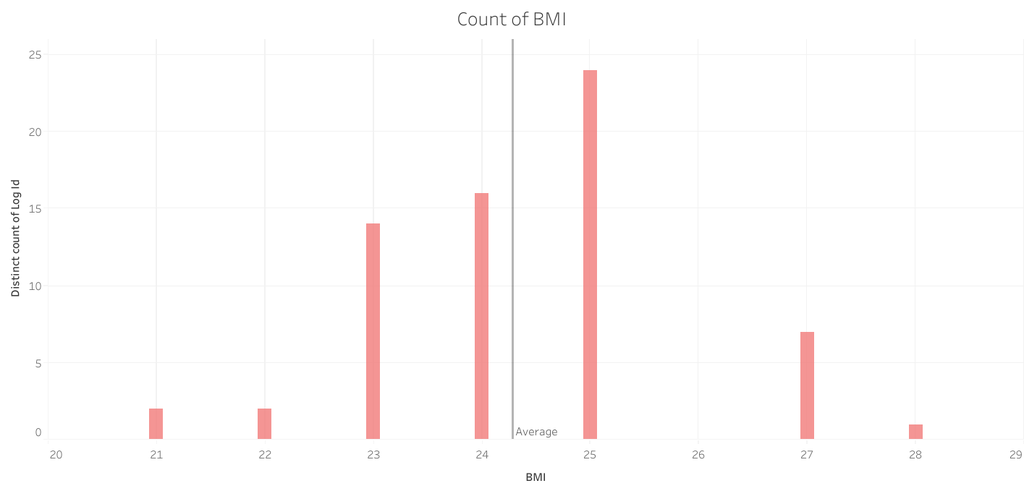

```r
knitr::include_graphics("C:/Users/33775/Downloads/BMI.png")
```

The bar chart visualizes the distribution of BMI (Body Mass Index) values among participants, with the count of distinct Log IDs represented on the vertical axis.

Small Sample Size: The distribution is not very broad, which might indicate that the dataset has a limited number of participants. This could affect the generalizability of the insights drawn from this data.

Then, i created a calculated measure to categorize BMI into four distinct classes, following the guidelines provided by the Australian Government’s Department of Health (source: health.gov.au):

- Underweight: BMI less than 18.5
- Healthy Weight: BMI between 18.5 and 24.9
- Overweight but Not Obese: BMI between 25 and 29.9
- Obese Class I: BMI between 30 and 34.9
- This categorization allows for a more detailed analysis of participants’ BMI distributions according to standardized health guidelines.

Mesure Formula : IF [BMI1]<18.5 THEN “Underweight” ELSEIF [BMI1]>=18.5 AND [BMI1]<25 THEN “Healthy Weight” ELSEIF [BMI1]>=25 AND [BMI1]<30 THEN “Overweight” ELSEIF [BMI1]>=30 THEN “Obesity” END

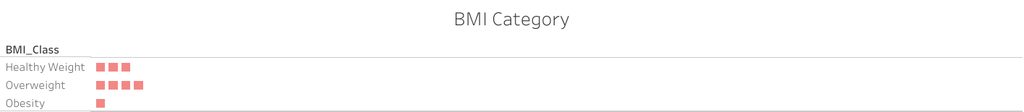

```r
knitr::include_graphics("C:/Users/33775/Downloads/BMI CLASS.png")
```

Based on our sample, it’s evident that there are no individuals in the underweight category. As observed from the distribution above, the data reveals that 3 participants fall within the healthy weight range, 4 are categorized as overweight, and 1 is classified as obese.

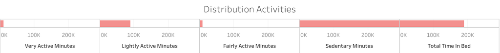

```r
knitr::include_graphics("C:/Users/33775/Downloads/Distribution Activities.png")
```

In summary, the chart suggests that the general population tends to be more sedentary or spend a lot of time in bed, while moderate and high levels of physical activity are less common.

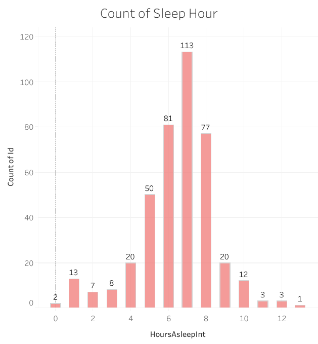

```r
knitr::include_graphics("C:/Users/33775/Downloads/Count of Sleep Hour.png")
```

In summary, the chart shows a normal distribution pattern in the count of sleep hours, with the majority of individuals sleeping around 7-8 hours per night, and fewer people exhibiting shorter or longer sleep durations.

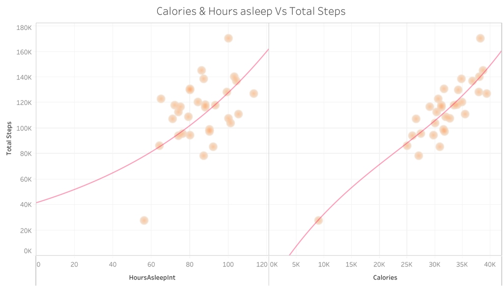

```r
knitr::include_graphics("C:/Users/33775/Downloads/Calories & Hours asleep Vs Total Steps.png")
```

2- Relationship between calories and total steps: The scatter plot also shows a positive correlation between calories burned and total steps. As the total number of steps increases, the number of calories burned also tends to increase.

3- Variation in the data: There is a significant amount of variation in the data points, indicating that the relationship between sleep, calories, and steps is not perfectly linear. There are many outliers and data points that do not strictly follow the overall trend.

4- Potential insights for Bellabeat: This data could provide insights for Bellabeat on how their customers use fitness trackers and how sleep, activity, and calorie burn are related. Bellabeat could use these insights to inform their product development, marketing strategies, and recommendations to customers.

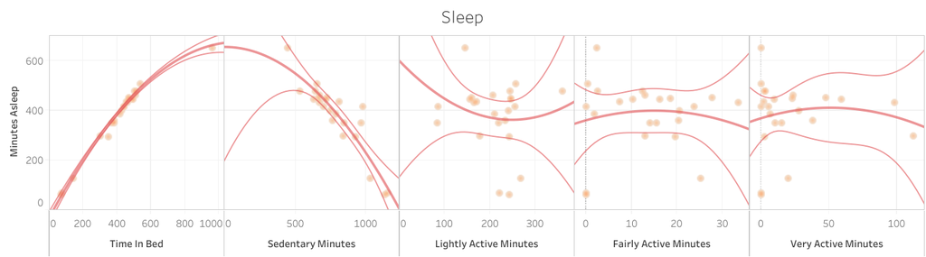

```r
knitr::include_graphics("C:/Users/33775/Downloads/Sleep.png")
```

Positive Correlation (Time in Bed):

1- Vertical Positive Trend Line: The first chart (Time in Bed vs. Minutes Asleep) shows a strong positive correlation, evidenced by the upward sloping trend line. This indicates that the more time users spend in bed, the longer they sleep. This is a clear and expected relationship, confirming that time in bed is a significant factor in determining sleep duration. Negative Correlation (Sedentary Minutes):

2- Vertical Negative Trend Line: The second chart (Sedentary Minutes vs. Minutes Asleep) shows a negative correlation. The trend line slopes downward, suggesting that higher sedentary minutes may be associated with less sleep, though the relationship is not as strong as with time in bed. This could indicate that spending excessive time being inactive might negatively impact sleep quality. No Significant Correlation (Lightly Active, Fairly Active, and Very Active Minutes):

3- Horizontal Trend Lines: The last three charts (Lightly Active, Fairly Active, and Very Active Minutes vs. Minutes Asleep) show horizontal trend lines, indicating little to no correlation between these activity levels and sleep duration. This suggests that moderate to high levels of activity during the day do not have a direct or significant impact on the amount of sleep.

– Recommendations for Bellabeat:

Encourage Healthy Bedtime Routines: Since time in bed has a strong positive correlation with sleep duration, Bellabeat could emphasize the importance of a consistent bedtime routine in its app. Features such as bedtime reminders and sleep goals could help users improve their sleep duration.

Monitor and Manage Sedentary Behavior: The negative correlation between sedentary minutes and sleep duration suggests that reducing sedentary behavior might improve sleep. Bellabeat could introduce features that encourage users to take breaks from inactivity, such as gentle reminders to move after prolonged periods of sitting.

Balance Activity Levels: Although lightly, fairly, and very active minutes show little correlation with sleep duration, it’s still important to maintain a balanced level of daily activity for overall health. Bellabeat could continue to promote balanced activity levels while focusing on other factors, like stress management and mindfulness, that might more directly affect sleep.

Personalized Sleep Insights: Bellabeat could provide users with personalized insights and suggestions based on their specific activity and sleep patterns. For instance, if a user has high sedentary minutes but low sleep duration, the app could recommend ways to integrate more active breaks during the day.

Comprehensive Health Monitoring: Since sleep is influenced by various factors beyond just physical activity, Bellabeat might consider offering more comprehensive health monitoring, including stress levels, diet, and mental well-being, to provide users with a holistic approach to improving their sleep and overall health.

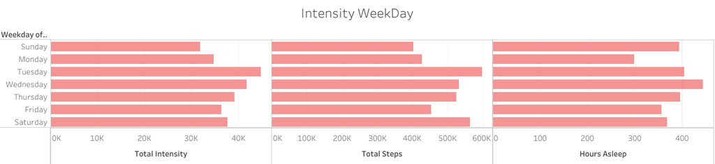

```r
knitr::include_graphics("C:/Users/33775/Downloads/Intensity WeekDay.png")
```

- Recommendations for Bellabeat:

Rest Day Encouragement: The lower intensity on Sundays could be an indication of rest days. Bellabeat might offer content on the importance of rest and recovery, helping users to understand how to balance intense activities with adequate rest for optimal health.

## Here is the final outcome of our work: a dashboard meticulously created in Tableau.

[figure not shown]

```r
knitr::include_graphics("C:/Users/33775/Downloads/Bellabeat Dashboard.png")
```

This comprehensive dashboard for the Bellabeat Case Study [Click here to view the Tableau Dashboard](https://public.tableau.com/app/profile/salah.eddine.el.khirani/viz/BellabeatCaseStudy_17229367718810/Dashboard1) provides a wealth of insights into user activity patterns, sleep habits, and health metrics. The visualizations effectively showcase the relationships between various aspects of users’ daily routines, including steps taken, calories burned, sleep duration, and activity intensity across different days of the week. The BMI distribution chart offers a quick overview of the user base’s health status, while the sleep analysis graphs reveal intricate patterns in sleep quality and duration relative to different activity levels. The weekday intensity chart highlights how user behaviors vary throughout the week, potentially informing targeted marketing strategies. This dashboard serves as a powerful tool for Bellabeat to understand their customers’ habits and tailor their products and services accordingly, ultimately supporting their goal of becoming a larger player in the global smart device market for women’s health.

Based on the analysis provided in the Bellabeat case study, here are the key findings and recommendations:  
## Key Findings  
1. Activity Patterns: - There’s wide variation in activity levels among users, with daily steps ranging from 4 to 36,019 (mean: 8,319). - Most users engage in light activity, with less time spent on moderate or intense activities. - Sedentary time is high, averaging nearly 16 hours per day.

By implementing these recommendations, Bellabeat can create a more engaging, personalized experience for users, potentially leading to improved health outcomes and increased user retention.

## Next Steps

To further improve this analysis, we could:

1. Collect more data over a longer period to identify long-term trends.
2. Gather demographic information to segment users and tailor marketing strategies.
3. Conduct a survey to understand user motivations and preferences.